# Midterm One

In this midterm we will analyze some data on the conservation status of species in North America and spending under the Endangered Species Act.

Answer the following questions by using chunks of R code. Comment on what your code does. Make sure to add informative axis titles and, where appropriate, units to your answers. Upload the R markdown file and knitted output to Canvas.

We will use the file `conservationdata.csv`. This dataset has information on North American species. It has five variables that are described in the table below.

Table 1. Variables in “consevationdata.csv”

| Name | Description |
| --- | --- |
| speciesid | unique ID |
| speciesname | scientific name |
| taxon | Species group |
| conservation status | Conservation status in North America, according to [NatureServe](https://www.natureserve.org/conservation-tools/conservation-rank-calculator): 1 = Critically Imperiled; 2 = Imperiled; 3 = Vulnerable; … |
| listed | Is the species listed as threatened or endangered under the US Endangered Species Act: 0 = No; 1 = Yes |

Read the file `conservationdata.csv`

```r
nmsdata <- read.csv("C:/Users/eddie/Downloads/conservationdata.csv")
```

1. What fraction of species in the dataset are listed under the Endangered Species Act? (2 points) Given: “Is the species listed as threatened or endangered under the US Endangered Species Act: 0 = No; 1 = Yes”

```r
endangered <- sum(nmsdata$listed == "1", na.rm = TRUE)
endangered
```

```
## [1] 1617
```

```r
total_species <- nrow(nmsdata)
fract <- endangered / total_species
fract
```

```
## [1] 0.0301353
```

```r
#it is 0.0301353
```

2. Show how many (absolute and relative) species there are for each taxonomic group by making a data.frame in which the first column has the taxonomic groups, the second column is the number of species in that group, and the third column is the percentage of all species in that group.

```r
speciessum <- data.frame(
  TaxonomicGroup = unique(nmsdata$taxon),
  NumberOfSpecies = rep(0, length(unique(nmsdata$taxon))),
  PercentageOfSpecies = rep(0, length(unique(nmsdata$taxon)))
)

for (i in 1:length(unique(nmsdata$taxon))) {
  current_group <- unique(nmsdata$taxon)[i]
  speciessum[i, "NumberOfSpecies"] <- sum(nmsdata$taxon == current_group)
  speciessum[i, "PercentageOfSpecies"] <- (speciessum[i, "NumberOfSpecies"] / total_species) * 100
}

speciessum
```

```
##   TaxonomicGroup NumberOfSpecies PercentageOfSpecies
## 1  Invertebrates           24407          45.4862276
## 2          Fungi            6270          11.6851169
## 3         Fishes            1453           2.7078907
## 4     Amphibians             319           0.5945059
## 5       Reptiles             350           0.6522793
## 6         Plants           19511          36.3617727
## 7          Birds             795           1.4816057
## 8        Mammals             474           0.8833725
## 9       Protists              79           0.1472287
```

3a) One interesting question is how the conservation status varies between different taxonomic groups. Make a plot showing the relative distribution of conservation status within each taxonomic group. There should be descriptive legend (with words, not with the numeric codes) (3 points)

You can use a “base” plotting method, or ggplot.

If you are using ggplot, stat=“count” (counts up and plots the number of observations, i.e. species, within each group) and position=“fill” might both be useful.

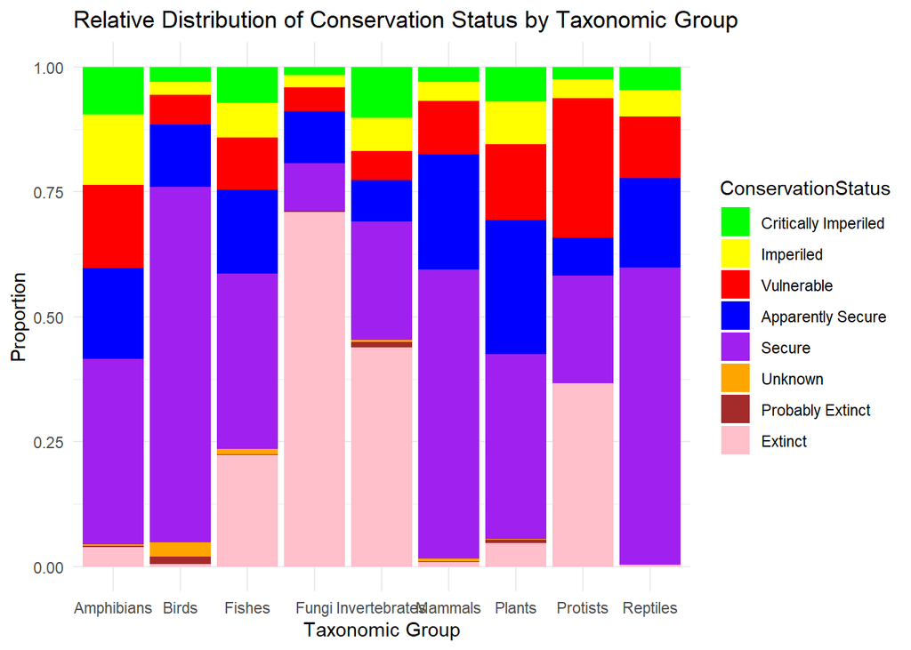

```r
library(ggplot2)


count <- table(nmsdata$taxon, nmsdata$conservation_status)


count_long <- as.data.frame.table(count)


colnames(count_long) <- c("TaxonomicGroup", "ConservationStatus", "Count")


ggplot(count_long, aes(x = TaxonomicGroup, y = Count, fill = ConservationStatus)) +
    geom_bar(stat = "identity", position = "fill") +
    labs(title = "Relative Distribution of Conservation Status by Taxonomic Group",
         x = "Taxonomic Group", y = "Proportion") +
    scale_fill_manual(values = c("green", "yellow", "red", "blue", "purple", "orange", "brown", "pink", "gray"),
                      labels = c("Critically Imperiled", "Imperiled", "Vulnerable",
                                 "Apparently Secure", "Secure", "Unknown",
                                 "Probably Extinct", "Extinct")) +
    theme_minimal()
```

3b) Based on this graph, what is something we might be concerned about in terms of analyzing the data on conservation status, particularly for fungi and invertebrates? (1 point)

**Answer:** The figure shows the high proportion of species classified as “extinct” or “probably extinct” among fungal and invertebrate taxa. Secondly, there are many species of invertebrates showing Critical Imperial. High rates of extinction may bias the conservation status of these species. This information gap may hinder accurate conservation assessments of fungi and invertebrates

Read in the second data file: `spendingdata.csv`

```r
seconddata <- read.csv("C:/Users/eddie/Downloads/spendingdata.csv")
```

This dataset has a species ID that matches the species ID in the conservation dataset (speciesid), year, and the spending on conservation of that species (expressed in in 2015 dollars, i.e., accounting for inflation)

4a) Make a plot showing the distribution of spending in the year 2016 (3 points)

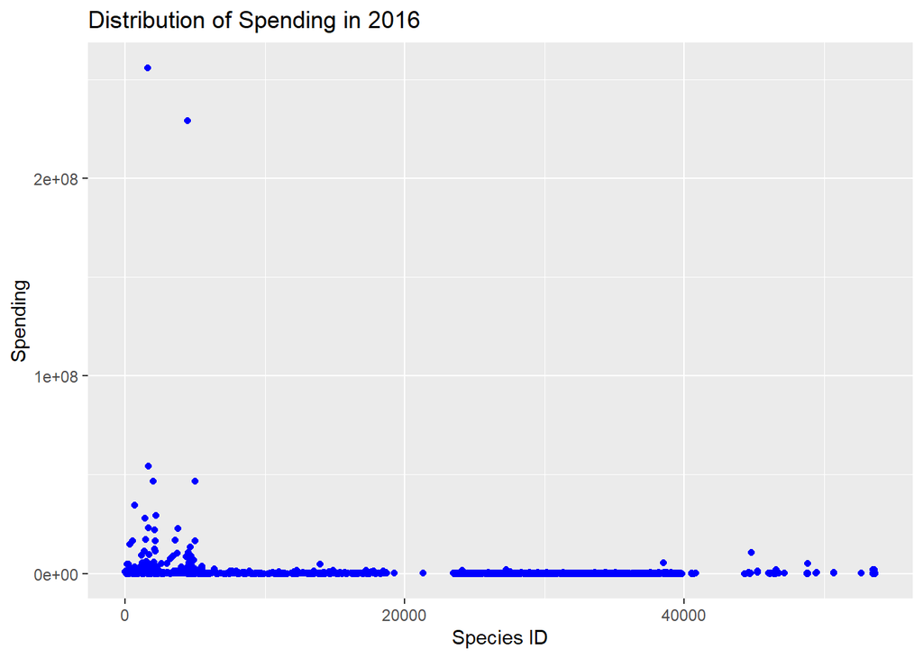

```r
library(ggplot2)
spending2016 <- subset(seconddata, Year == 2016)

ggplot(spending2016, aes(x = speciesid, y = spending)) +
  geom_point(color = "blue") +
  labs(title = "Distribution of Spending in 2016",
       x = "Species ID",
       y = "Spending")
```

4b) Notice the (very) long right tail on spending data - we spend a lot on a very small number of species. Show the IDs of the 3 species with the most spending in 2016. (2 points)

```r
top3 <- spending2016[order(spending2016$spending, decreasing = TRUE), ][1:3, ]
top3
```

```
##      speciesid Year  spending
## 2095      1632 2016 255893066
## 4627      4486 2016 229175092
## 2220      1684 2016  54122671
```

5. Merge in the data from the conservation status data frame to the spending data frame, so that we have information on species names, taxonomic group, and conservation status with the spending data. (2 points); and use that to show the scientific names of the three species identified above.

```r
merged_data = merge(spending2016, nmsdata, by = "speciesid",all.x = TRUE)
top3sspnames <- merged_data[merged_data$speciesid %in% top3$speciesid, "speciesname"]
top3sspnames
```

```
## [1] "Oncorhynchus tshawytscha" "Oncorhynchus kisutch"
## [3] "Oncorhynchus mykiss"
```

Look up these scientific names - what is the common name for these species?

**Answer:** Oncorhynchus tshawytscha , Oncorhynchus kisutch , Oncorhynchus mykiss, common names:Chinook salmon, Rainbow Trout, and Coho Salmon

6. Finally, we will use a regression to look at the relationship between spending and species taxon.

Because the distribution of spending is very right-skewed, it would be a good idea to take the logarithm of spending before using it in a regression.

Remember that log(0)=infinity. That means we have to drop observations with zero spending before taking the logarithm.

1. Drop the rows where spending == 0 from the data frame and then make a new column with the logarithm (log()) of spending in each year. (2 points)

```r
nonzero_spending <- seconddata[seconddata$spending != 0, ]
nonzero_spending$log_spending <- log(nonzero_spending$spending)
head(nonzero_spending)
```

```
##   speciesid Year spending log_spending
## 1     49476 2015 461812.9     13.04292
## 2     49476 2016 615705.5     13.33052
## 3     49477 2015 422095.3     12.95299
## 4     49477 2016 471121.0     13.06287
## 5        11 2014 956187.2     13.77071
## 6        11 2015 917124.9     13.72900
```

Optional: Look at the distribution of the logged spending variable and see how it looks different from the plot you made in question 4a

2. Run a regression of logged spending on taxonomic group and print the summary for the regression below (3 points)

```r
merged_zero_data = merge(nonzero_spending, nmsdata, by = "speciesid", all.x = TRUE)
str(merged_zero_data)
```

```
## 'data.frame':    26971 obs. of  8 variables:
##  $ speciesid          : int  11 11 11 11 11 11 11 11 11 11 ...
##  $ Year               : int  2014 2015 2016 1996 1997 1998 1999 2000 2001 2002 ...
##  $ spending           : num  956187 917125 1014963 851367 353143 ...
##  $ log_spending       : num  13.8 13.7 13.8 13.7 12.8 ...
##  $ speciesname        : chr  "Balaena mysticetus" "Balaena mysticetus" "Balaena mysticetus" "Balaena mysticetus" ...
##  $ taxon              : chr  "Mammals" "Mammals" "Mammals" "Mammals" ...
##  $ conservation_status: chr  "3" "3" "3" "3" ...
##  $ listed             : int  1 1 1 1 1 1 1 1 1 1 ...
```

```r
regression_model = lm(log_spending ~ taxon, data = merged_zero_data)
summary(regression_model)
```

```
##
## Call:
## lm(formula = log_spending ~ taxon, data = merged_zero_data)
##
## Residuals:
##     Min      1Q  Median      3Q     Max
## -8.7311 -1.1848  0.0171  1.3813  7.4867
##
## Coefficients:
##                    Estimate Std. Error t value Pr(>|t|)
## (Intercept)        11.64222    0.09488 122.700  < 2e-16 ***
## taxonBirds          0.87617    0.10555   8.301  < 2e-16 ***
## taxonFishes         0.43339    0.10266   4.222 2.43e-05 ***
## taxonFungi         -1.63702    0.32276  -5.072 3.97e-07 ***
## taxonInvertebrates -0.64918    0.09927  -6.540 6.28e-11 ***
## taxonMammals        1.03077    0.10690   9.643  < 2e-16 ***
## taxonPlants        -1.92320    0.09628 -19.975  < 2e-16 ***
## taxonReptiles       0.48029    0.12093   3.972 7.16e-05 ***
## ---
## Signif. codes:  0 '***' 0.001 '**' 0.01 '*' 0.05 '.' 0.1 ' ' 1
##
## Residual standard error: 1.999 on 26963 degrees of freedom
## Multiple R-squared:  0.2402, Adjusted R-squared:   0.24
## F-statistic:  1218 on 7 and 26963 DF,  p-value: < 2.2e-16
```

3. The way to interpret these coefficients are as the fractional difference in spending between the taxonomic group (e.g. Birds, Fishes etc) and the “dropped” group, where by default the dropped group will be Amphibians. Positive numbers indicate that group has more spent on it than Amphibians and negative numbers indicate it has less spent on it.

Based on your results in b, do we see statistically significant differences in spending between different taxonomic groups? If so, which kinds of species tend to have more spent on them and which have less? (1 points)

**Answer:** Birds, fish, reptiles, and mammals tend to have significantly more spending compared to Amphibians. Fungi, plants, and invertebrates tend to have significantly less spending compared to Amphibians.

7. Push your R markdown file to your Github repository (2 points) ✔